# Palmetto Binary Logistic Regression

Anastasia Kunz

2/2/2021

```r
palmetto <- read_csv(here("data", "palmetto.csv"),
                     col_types = cols(.default = 'c')) %>%
  mutate(height = as.numeric(height)) %>%
  mutate(length = as.numeric(length)) %>%
  mutate(width = as.numeric(width)) %>%
  mutate(species = as.factor(species)) %>%
  mutate(green_lvs = as.numeric(green_lvs)) %>%
  mutate(species_full = case_when(species == "1" ~ "Serenoa repens",
                                  species == "2" ~ "Sabal etonia")) %>%
  mutate(species_full = as.factor(species_full))

palmetto_subset <- palmetto %>%
  select(species, species_full, height, length, width, green_lvs)
```

## Data Visualizations

```r
#Height Plot
height_plot <-ggplot(data = palmetto_subset, aes(x = species_full, y = height))+
  geom_boxplot()+
  geom_jitter(aes(color= species_full), size=0.3, alpha=0.1) +
  theme_minimal()+
  labs(
    x = "Species",
    y = "Tree Height (cm)",
    title = "Tree Height by Species"
  )+
  theme(legend.position = "none")


# Length Plot
length_plot <- ggplot(data = palmetto_subset, aes(x = species_full, y = length))+
  geom_boxplot()+
  geom_jitter(aes(color= species_full), size=0.3, alpha=0.1) +
  theme_minimal()+
  labs(
    x = "Species",
    y = "Tree Canopy Length (cm)",
    title = "Tree Canopy Length by Species"
  )+
  theme(legend.position = "none")


# Width Plot
width_plot <-ggplot(data = palmetto_subset, aes(x = species_full, y = width))+
  geom_boxplot()+
  geom_jitter(aes(color= species_full), size=0.3, alpha=0.1) +
  theme_minimal()+
  labs(
    x = "Species",
    y = "Tree Canopy Width (cm)",
    title = "Tree Canopy Width by Species"
  )+
   theme(legend.position = "none")

# Green Leaves  BOX Plot
grn_lvs_plot <- ggplot(data = palmetto_subset, aes(x = species_full, y = green_lvs))+
  geom_boxplot()+
  geom_jitter(aes(color= species_full), size=0.3, alpha=0.1) +
  theme_minimal()+
  labs(
    x = "Species",
    y = "Number of Green Leaves",
    title = "Number of Green Leaves by Species"
  )+
   theme(legend.position = "none")
```

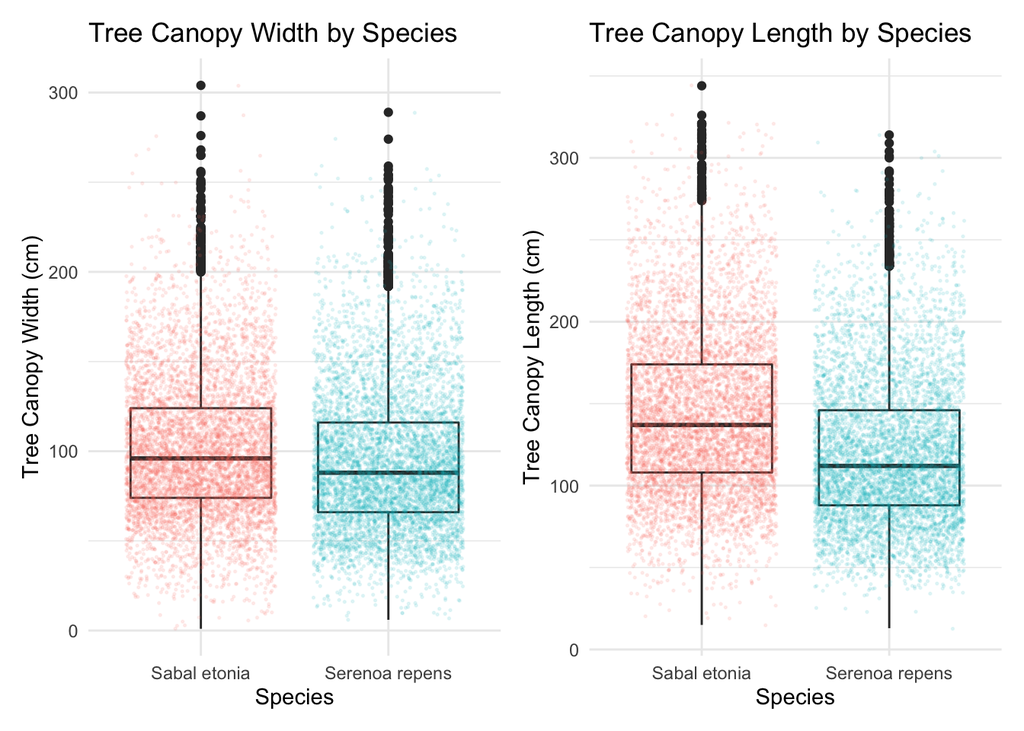

```r
patchwork_lw <- (width_plot+ length_plot)
patchwork_lw
```

### 1. Canopy Length & Width Analysis

Between the two species of palmettos, canopy width and canopy length are relatively similar. Canopy length analysis shows that *Sabal etonia* has slightly higher average canopy width than *Serenoa repens*. This same dynamic is more pronounced in canopy length, with *Sabal etonia* having greater length than *Serenoa repens*.

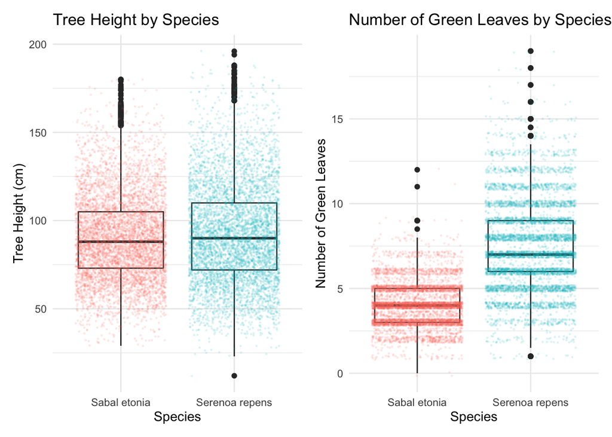

**Figure 2.** Boxplots comparing the average and distribution of tree height (left) and the number of green leaves (right) between two species of palmettos, *Serenoa repens* and *Sabal etonia*.

```r
patchwork_hg <- (height_plot + grn_lvs_plot)
patchwork_hg
```

### 2. Height & Green Leaves Analysis

Similar to canopy length and width, tree height also looks relatively similar with a more broad distribution in *Serenoa repens*. However, when comparing the number of green leaves between the two species we see that on average, *Serenoa repens* has a greater average number of green leaves than *Sabal etonia*. It is important to note that the distribution of green leaves is not normal, and it is helpful to explore the distribution through a histogram.

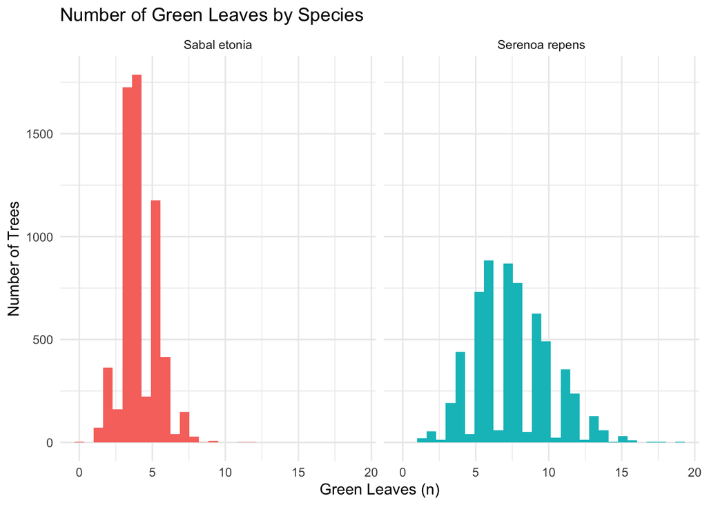

**Figure 3.** Histogram showing the distribution of the number of green leaves between *Serenoa repens* and *Sabal etonia*.

```r
# Green Leaves Plot
grn_lvs_histogram <- ggplot(data = palmetto_subset, aes(x = green_lvs, fill = species_full))+
  geom_histogram()+
  facet_wrap(~ species_full)+
  theme_minimal()+
  labs(
    x = "Green Leaves (n)",
    y = "Number of Trees",
    title = "Number of Green Leaves by Species"
  )+
   theme(legend.position = "none")
grn_lvs_histogram
```

### 3. Green Leaves Histogram Analysis

Looking at this histogram we see a comb distribution for both species. *Sabal etonia* has a much more concentrated distribution than *Serenoa repens*.

## Binary Logistic Regression

**Table 1.** Binary logistic regression model outputs showing coefficients for each variable used in the model as well as the standard error, statistic and rounded p value.

```r
palmetto_blr <- glm(species_full ~ length + width + height + green_lvs,
                            data = palmetto_subset,
                            family = "binomial")


palm_table <- tidy(palmetto_blr) %>%
  mutate(p.value = case_when(p.value <= 0.0001 ~ "< 0.0001"))

palm_table %>%
  kbl() %>%
  kable_styling(bootstrap_options = c("striped", "hover"))
```

| term | estimate | std.error | statistic | p.value |
| --- | --- | --- | --- | --- |
| (Intercept) | -3.2266851 | 0.1420708 | -22.71180 | < 0.0001 |
| length | -0.0458233 | 0.0018661 | -24.55600 | < 0.0001 |
| width | -0.0394434 | 0.0021000 | -18.78227 | < 0.0001 |
| height | 0.0292173 | 0.0023061 | 12.66984 | < 0.0001 |
| green_lvs | 1.9084747 | 0.0388634 | 49.10728 | < 0.0001 |

### Model Evaluation

```r
blr_fitted <-palmetto_blr %>%
  broom::augment(type.predict = "response")

blr_matrix <- blr_fitted %>%
  mutate(predicted = case_when(.fitted >= 0.50 ~"Serenoa repens",
                               .fitted < 0.50 ~ "Sabal etonia")) %>%
  mutate(correct =  case_when(species_full == predicted ~ "Correct",
                              TRUE ~ "Incorrect")) %>%
  group_by(species_full, correct) %>%
  summarize(correct_totals = n()) %>%
  pivot_wider(names_from = correct, values_from = correct_totals) %>%
  group_by(species_full, Correct, Incorrect) %>%
  summarize(total = sum(Correct, Incorrect),
            percent_correct = (Correct/total*100)) %>%
  select(species_full, Correct, Incorrect, percent_correct)
```

**Table 2.** Binary logistic regression model results showing number of species correctly classified, incorrectly classified, and the total percent correctly classified.

```r
kbl(blr_matrix, col.names = c("Species", "Correct", "Incorrect", "Percent Correct")) %>%
    kable_styling(bootstrap_options = c("striped", "condensed"), full_width = T) %>%
    column_spec(1, bold = TRUE, background = "white")
```

| Species | Correct | Incorrect | Percent Correct |
| --- | --- | --- | --- |
| Sabal etonia | 5701 | 454 | 92.62388 |
| Serenoa repens | 5548 | 564 | 90.77225 |

## Citation

Abrahamson, W.G. 2019. Survival, growth and biomass estimates of two dominant palmetto species of south-central Florida from 1981 - 2017, ongoing at 5-year intervals ver 1. Environmental Data Initiative. https://doi.org/10.6073/pasta/f2f96ec76fbbd4b9db431c79a770c4d5